## Counterfactual Estimation

## Nelson Auner

> Instructions Let’s assume that it’s for a clickthrough-prediction model; each row represents an ad that you are > deciding whether to show the user or not. The first column represents the ground truth of whether or not the user will click it; the second column is the probability, output by the model, that the user will click it.

> Let’s assume our strategy is to show an ad whenever the probability is > 0.7. As a first step, write a script that outputs the precision of that strategy given this data.

We use $precision := \frac{true positives}{all positives}$

```r
library(magrittr) # Ceci n'est pas un pipe
library(dplyr) # for easy filtering, aggregation

scores= read.csv("scores.tsv",sep="\t",header=FALSE)
names(scores) = c("clicked","model_prob")


scores %>%
  filter(model_prob >= .7) %>% #examine only shown ads
  select(clicked) %>%
  table %T>% print %>%
  (function(x) {print("precision rate is:") ; x["true"] / sum(x)})
```

```
## .
## false  true
##     3    35
## [1] "precision rate is:"
```

```
##      true
## 0.9210526
```

> Now, consider the case where our ground truth data is incomplete (because we only actually get labels for cases when we *did* show the ad, not when we chose not to). This paper outlines a strategy for evaluating new models in that situation: http://arxiv.org/pdf/1403.1891.pdf

> Please write two scripts:
> - One simulates the actual ad display; it takes the scores.tsv as input, and produces a log file as output. The log file will be our new, incomplete ground truth data for model evaluation. The log file should include the model’s probability output, some indication of whether the ad was shown, and *in the cases in which the ad was shown*, it should include the label from scores.tsv (indicating whether the user clicked it). Whether the ad was shown should *approximate* the “probability > 0.7” strategy from above. Include any other info in the log file that is useful.

As the paper mentions, the strategy to show ads must have propensity scores $p = (p_1, p_2, ..., p_K)$ such that $p_i > 0 \forall i \in 1,..K$

This means that instead of using a sharp cutoff, we need a smoother mapping to show ads. We’ll use (for convenience) a linear piecewise function with a jump at the cutoff, but the script can be adapted to take in other functions

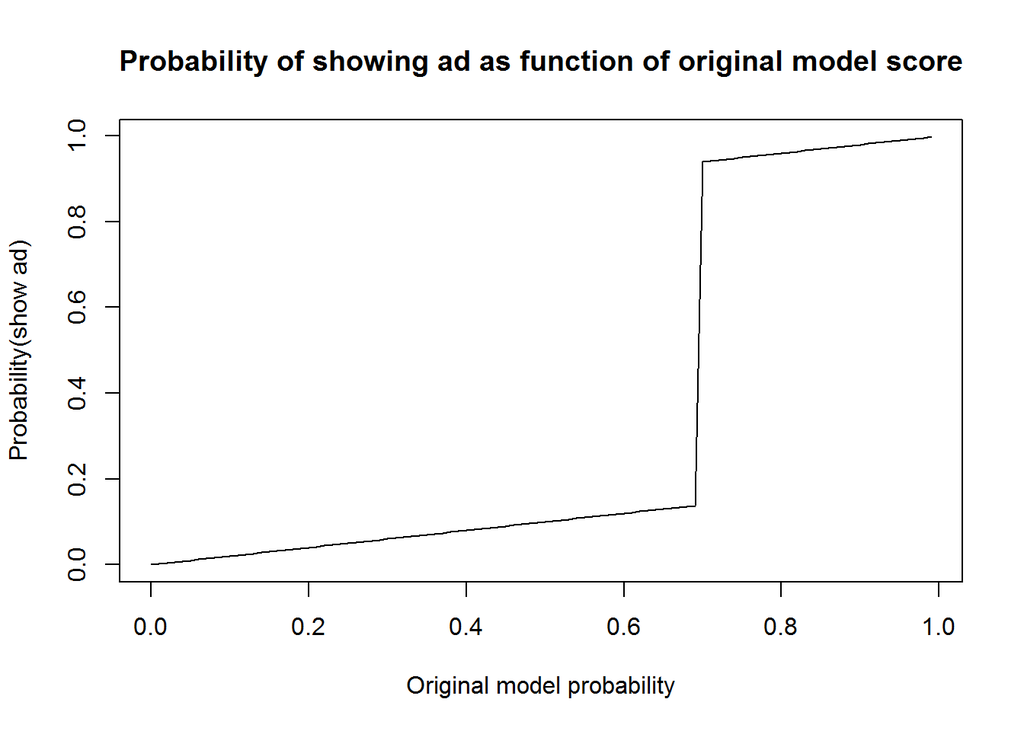

```r
  linear_piecewise <- function(score,cutoff=.7,slope=.2) {
    if (score < cutoff) {
      return(score*slope)
                         } else if (score > cutoff) {
                           (return(1-slope+score*slope))
                           }
  }

#demo function + quick visual check:
temp <- seq(0,.99,.01)
sapply(temp,FUN = function(x) {linear_piecewise(x,.7)}) %>% plot(temp,y=.,type="l",main="Probability of showing ad as function of original model score",ylab="Probability(show ad)",xlab="Original model probability")
```

We then bundle the decision function into a wrapper that produces a log. As the paper suggests, we’ll also keep track of the randomly generated number `rand_log`used to produce action $a$ from the propensity scores $p$, so we can check later for errors.

We examine the output of the log to make sure that the new strategy approximates the original strict cutoff strategy

```r
show_ads <- function(scores,cutoff,prob_function=linear_piecewise) {
  # create probabilities via function
  scores$new_model_prob <- sapply(scores$model_prob, FUN = function(x) {
    linear_piecewise(x,cutoff)
    })
  # and assign them
  scores$rand_log = runif(length(scores$model_prob))
  scores$show = scores$new_model_prob > scores$rand_log
  #and you only see
return(scores)
}

res <- show_ads(scores,.7)

new_scores <-
scores %>% show_ads(.7) %>% arrange(-new_model_prob) %T>%
  (function(x) {print(head(x,10));print(tail(x,10))})
```

```
##    clicked model_prob new_model_prob   rand_log show
## 1     true  0.8989479      0.9797896 0.78625075 TRUE
## 2     true  0.8814975      0.9762995 0.92367836 TRUE
## 3     true  0.8589375      0.9717875 0.20933500 TRUE
## 4     true  0.8556315      0.9711263 0.28756213 TRUE
## 5     true  0.8544739      0.9708948 0.87011898 TRUE
## 6     true  0.8524288      0.9704858 0.35609393 TRUE
## 7     true  0.8491713      0.9698343 0.29388833 TRUE
## 8     true  0.8486073      0.9697215 0.92229781 TRUE
## 9     true  0.8253459      0.9650692 0.14044315 TRUE
## 10    true  0.8145312      0.9629062 0.01559187 TRUE
##      clicked  model_prob new_model_prob    rand_log  show
## 991    false 0.004421659   0.0008843317 0.382724768 FALSE
## 992    false 0.004421659   0.0008843317 0.000512959  TRUE
## 993    false 0.004364137   0.0008728273 0.077692693 FALSE
## 994    false 0.004330289   0.0008660577 0.109085828 FALSE
## 995    false 0.004278096   0.0008556192 0.625535084 FALSE
## 996    false 0.004270949   0.0008541898 0.914718875 FALSE
## 997    false 0.004270949   0.0008541898 0.247543902 FALSE
## 998    false 0.004270949   0.0008541898 0.666717485 FALSE
## 999    false 0.004270949   0.0008541898 0.888239341 FALSE
## 1000   false 0.002755104   0.0005510209 0.324803152 FALSE
```

```r
#how similar is precision to exact cutoff strategy?


new_scores %>%
  filter(show==TRUE) %>%
  select(clicked) %>%
  table %T>% print %>%
  (function(x) {print("precision rate is:") ; x["true"] / sum(x)})
```

```
## .
## false  true
##     7    36
## [1] "precision rate is:"
```

```
##      true
## 0.8372093
```

> - Another uses the simulator log to evaluate prospective models; it takes the log file as input, along with a threshold probability (i.e., maybe you want to evaluate using 0.5 instead of 0.7 as the threshold). It should produce an estimate of the precision that would result from using that threshold, using the method from the paper.

The estimator described in the paper is

$\hat{V}_{offline} := \sum{\frac{r_a 1_{\pi(x) = a}}{p_a}}$

It should approximate the average reward $V(\pi) = E[r_\pi(x)]$

We use

1. $r_a$ is the reward of show/no show, and is 1 if shown and clicked and 0 if shown and not clicked.
2. $\pi(x) = a$ devides the data into situations where ads were shown vs. not shown
3. $p_a$ is the probability that we would show the ad to a given user, represented in the code by `new_model_prob`

```r
v_hat_offline <- function(new_scores,cutoff) {
  #input: new_scores: result of show_ads
  new_scores$clicked_bool <- new_scores$clicked=="true"
  new_scores$numerator <-
    new_scores$show * new_scores$clicked_bool  # r_a is "clicked", 1{pi(x)=a} is "show"

  new_scores$denominator <- new_scores$new_model_prob #prob of show given environment x
  new_scores$frac <-  new_scores %$% `/`(numerator,denominator)
  return(new_scores)
}

res <- scores %>% show_ads(cutoff=.7) %>% v_hat_offline(cutoff=.7)
```